# Poll Aggregators

## In-class questions

We’re going to try something new today. If you have small technical questions during class, go to this [link](https://docs.google.com/document/d/1rClyG2ZMoTM9tER9zjXCBT-26lrpuIH_oSkCLCI6pII/edit?usp=sharing) and ask away.

## Averaging polls

```
##                     pollster diff Obama Romney margin_of_error    n
## 1                     Gallup   -1    48     49            2.00 2551
## 2                  Rasmussen   -1    48     49            3.00 1500
## 3                   Monmouth    0    48     48            2.60 1417
## 4                        ARG    0    49     49            3.00 1200
## 5  Politico/GWU/Battleground    0    47     47            3.10 1000
## 6           Gravis Marketing    0    48     48            3.30  872
## 7                        CNN    0    49     49            3.50  693
## 8                    NBC/WSJ    1    48     47            2.55 1475
## 9                   IBD/TIPP    1    50     49            3.70  712
## 10     DailyKos/SEIU/PPP (D)    2    50     48            2.70 1300
## 11                       PPP    2    50     48            2.80 1200
## 12                       Pew    3    48     45            2.20 2709
## 13                  ABC/Post    3    50     47            2.50 2345
```

Given that so many polls pointed to a toss up, why was Nate Silver so confident?

## Competition Data

Let’s start by looking at our competition data.

```r
library(readr)
filename <- "https://raw.githubusercontent.com/datasciencelabs/data/master/blue-bead-comp-results.csv"
tab <- read_csv(filename)
names(tab)<-c("timestamp", "name", "estimate","N","ci")
```

Looking at the data, are there more blue or red balls?

BTW, the winners are:

```r
date <- sapply(strsplit(tab$timestamp," "), function(x)x[1])
date <- as.Date(date,"%m/%d/%Y")
tab %>% mutate(date = date) %>% filter(date<"2016-02-23") %>%
  mutate(diff = abs(estimate - 53.4)) %>% arrange(diff)
```

```
## Source: local data frame [50 x 7]
##
##             timestamp        name estimate     N         ci       date
##                 (chr)       (chr)    (dbl) (int)      (chr)     (date)
## 1  2/21/2016 22:02:59      Ritong       53   100          2 2016-02-21
## 2  2/21/2016 23:53:55    students       53   100          2 2016-02-21
## 3  2/21/2016 13:18:42         Red       54    25          2 2016-02-21
## 4  2/21/2016 21:53:08 Yogesh Naik       54   100          4 2016-02-21
## 5  2/17/2016 10:20:22    Shengyao       52    50  0.47~0.57 2016-02-17
## 6  2/20/2016 15:43:09 ZHIMIN XIAO       52   100 48% TO 54% 2016-02-20
## 7  2/21/2016 21:50:58       Orion       52    76          2 2016-02-21
## 8  2/17/2016 10:05:34          JY       55    50          5 2016-02-17
## 9  2/20/2016 23:02:16       Mohan       55    40    [40-70] 2016-02-20
## 10 2/21/2016 21:39:22          pk       55    20          8 2016-02-21
## ..                ...         ...      ...   ...        ...        ...
## Variables not shown: diff (dbl)
```

Now back to aggregating:

```r
tab <- mutate(tab,estimate=ifelse(estimate<1, estimate*100, estimate))
boxplot(tab$estimate)
```

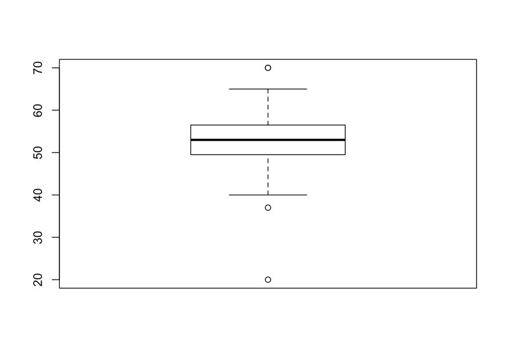

[figure not shown]

```r
tab = filter(tab, estimate>20)
```

So now it’s my turn to enter a competing entry.

We can assume that all these entries were based on independent data. So this data actually shows data for

```r
tab %>% summarise(sum(N))
```

```
## Source: local data frame [1 x 1]
##
##   sum(N)
##    (int)
## 1   4397
```

We can deduce how many blue and red beads the first person saw:

```r
slice(tab,1)
```

```
## Source: local data frame [1 x 5]
##
##           timestamp  name estimate     N    ci
##               (chr) (chr)    (dbl) (int) (chr)
## 1 2/17/2016 8:59:41  blue       50   100 40-60
```

In general we know each person saw

```r
tab %>% mutate(blue = estimate/100 * N, red = (1-estimate/100) * N) %>% select(blue, red)
```

```
## Source: local data frame [54 x 2]
##
##     blue   red
##    (dbl) (dbl)
## 1  50.00 50.00
## 2  50.00 50.00
## 3  27.50 22.50
## 4  24.00 26.00
## 5  26.00 24.00
## 6   5.85  3.15
## 7  49.00 51.00
## 8   8.55  6.45
## 9  17.08 10.92
## 10 14.00 21.00
## ..   ...   ...
```

So we can add these all up and create an estimate on thousands of draws:

We have $k=1,\dots,K$ polls each with $N_k$ observations and en estimate $\hat{p}_k$. We can deduce then that for poll $k$, $N_k \hat{p}_k$ are blue. So the aggregate $\hat{p}$ is

$\frac{\sum_{k=1}^K \hat{p}_k N_k}{\sum_{k=1}^K N_k}$ which can be viewed as a weighted average:

$\sum_{k=1}^P w_k \hat{p}_k \mbox{ with } w_k = \frac{N_k}{\sum_{k=1}^K N_k}$

So our new estimate is

```r
N <- sum(tab$N)
p_hat <- sum(tab$estimate*tab$N)/N
```

And our confidence interval is pretty tight:

```r
c(-1,1)*qnorm(0.975)*sqrt(p_hat/100*(1-p_hat/100))/sqrt(N)*100
```

```
## [1] -1.475158  1.475158
```

## Back to the 2012 Election

Let’s compute this for Obama and Romney (we assume the undecided at random)

```r
O <- sum(polls$Obama*polls$observations)/sum(polls$observations)/100
R <- sum(polls$Romney*polls$observations)/sum(polls$observations)/100
```

and the difference is

```r
round(O-R,2)
```

```
## [1] 0.01
```

The margin of error for each one is:

```r
N <- sum(polls$observations)
round( qnorm(.975)*sqrt(O*(1-O))/sqrt(N), 3)
```

```
## [1] 0.007
```

```r
round( qnorm(.975)*sqrt(R*(1-R))/sqrt(N), 3)
```

```
## [1] 0.007
```

Now we have two confidence intervals? We can form a confidence interval for the difference. The difference is approximately $\hat{p} - (1-\hat{p})$ or $1-2\hat{p}$. This implies that the standard error for the difference is twice as large than for $\hat{p}$. So our confidence interval is:

```r
O-R + c(-2,2)*qnorm(.975)*sqrt(O*(1-O))/sqrt(N)
```

```
## [1] -0.004579769  0.023867215
```

So a 95% confidence interval still didn’t quite call the election for Obama (but it was close). However, as we will learn there was much more involved in the “90% chance of winning”" prediction which we will learn next.

## More Polls

#### Assessment:

Adapt the code above to make a plot of difference between Obama and Romney against time.